# Metrics and plots functions

Ander Alonso

2022-01-30

```r
library(SME)
library(knitr)
```

# variance

Variance is the expectation of the squared deviation of a random variable from its population mean or sample mean. Variance is a measure of dispersion, meaning it is a measure of how far a set of numbers is spread out from their average value:

$\sigma^2 = \sum_{1}^{n} \frac{(x_i - mean(x))^2}{n-1}$

### Usage

variance(x, margin = 2L)

### Arguments

- x : a numeric vector, matrix, or data.frame.
- margin: In case of matrix or dataframe apply variance by columns margin = 2L or by rows margin = 1L. Default 2.

### Value

the sample variance of the input.

### Examples

```r
example1 <- data.frame("V1" = rep(1, 100), "V2" = 100:1,  "V4" = sample.int(3000,100,replace=FALSE))
example2 <- rep(1, 100)
```

```r
v <- variance(example1)
kable(v)
```

|  | x |
| --- | --- |
| V1 | 0.0000 |
| V2 | 841.6667 |
| V4 | 743779.7580 |

```r
v <- variance(example1, margin = 1L)
print(v)
```

```
##   [1]  241304.3333    7444.0000   83533.0000  437025.3333 2804623.0000
##   [6]  228534.3333 1767796.3333  166384.0000  172717.0000 1304868.0000
##  [11] 2299730.3333  276757.3333  376072.3333    2409.3333  898886.3333
##  [16]   48639.0000 1573526.3333  116537.3333 2269731.0000  935692.0000
##  [21]  434380.3333   41657.3333    5929.0000   77924.3333 2405376.3333
##  [26] 1086174.3333    4436.3333 1570929.3333  288631.0000  781525.0000
##  [31]    3684.3333   43164.3333  158216.3333 2382732.0000   19230.3333
##  [36] 1749057.3333 2127042.3333 1009001.3333  185194.3333     900.3333
##  [41] 1153450.3333   94474.3333 1142262.3333 1055731.0000  698210.3333
##  [46] 2318652.0000 1869054.3333   63461.3333   25767.0000  785010.3333
##  [51]   86791.0000 1682081.3333    4192.3333  322625.3333  411576.3333
##  [56]   19365.3333  129216.3333  130233.0000  230884.3333  696408.3333
##  [61] 1329051.0000  996841.3333  629176.3333  165999.0000   14797.0000
##  [66] 1434114.3333 2313802.3333 2243201.3333 1851271.0000 1559748.0000
##  [71]  447584.3333 2532041.3333   64569.0000 2751545.3333 2384473.0000
##  [76]    3960.3333  317983.0000  638606.3333  425367.0000  408583.0000
##  [81]   62731.0000   89868.0000  248616.3333  127784.3333  119058.3333
##  [86] 1665124.0000    1942.3333   28263.0000  210440.3333 1292345.3333
##  [91]   21272.3333 1317397.3333  114282.3333   85017.3333  690726.3333
##  [96] 1484037.3333 1527249.0000 1422786.3333 1206502.3333 1329336.3333
```

```r
v <- variance(example2)
kable(v)
```

| x |
| --- |
| 0 |

## entropy

Entropy of a random variable is the average level of “information”, “surprise”, or “uncertainty” inherent to the variable’s possible outcomes.

$H(X)= -\sum_{1}^{n}P(x_i)log[P(x_i)]$

### Usage

entropy(x, margin = 2L)

### Arguments

- x : a numeric vector, matrix, or data.frame.
- margin: In case of matrix or dataframe apply entropy by columns margin = 2L or by rows margin = 1L. Default 2.

### Value

the sample entropy of the input.

### Examples

```r
col1 <-  c('False', 'False', 'True', 'True', 'True', 'True', 'False', 'True', 'False', 'False')
col2 <- c('True', 'False', 'False', 'False', 'True', 'True', 'False', 'False', 'False', 'False')
col3 <- c('a', 'b', 'c', 'a', 'a', 'a', 'l', 'a', 'l', 'a')
df <- data.frame("V1" = col1, "V2" = col2, "V3" = col3)
```

```r
e <- entropy(df)
kable(e)
```

|  | x |
| --- | --- |
| V1 | 1.0000000 |
| V2 | 0.8812909 |
| V3 | 1.5709506 |

# conditional.entropy

Conditional entropy quantifies the amount of information needed to describe the outcome of a random variable Y given that the value of another random variable X is known.

$H(X|Y) = -\sum\sum p(x,y)log[\frac{p(x,y)}{p(x)}]$

### Usage

conditional.entropy(x, y = NULL, file = “None”)

### Arguments

- x: a vector, matrix, or data.frame.
- y: a vector. y must be NULL if x is a matrix or a data.frame
- file: In case of x been a data.frame or matrix, represent the name of output file for saving conditional entropy plot

### Value

In case of x been a data.frame or matrix, conditional entropy of all variables/columns in x. Otherwise, conditional entropy of x and y.

### Examples

```r
df <- data.frame("V1" = sample.int(2,5,replace=TRUE), "V2" =sample.int(2,5,replace=TRUE) , "V3" = sample.int(2,5,replace=TRUE), "V4" = sample.int(2,5,replace=TRUE),  "V5" = sample.int(2,5,replace=TRUE), "V6" = sample.int(2,5,replace=TRUE), "V7" = sample.int(2,5,replace=TRUE), "V8" = sample.int(2,5,replace=TRUE))
x <- sample.int(2, 5,replace=TRUE)
y <- sample.int(2,5,replace=TRUE)
```

```r
c <- conditional.entropy(df, file ="conditionalEntropy")
kable(c)
```

|  | V1 | V2 | V3 | V4 | V5 | V6 | V7 | V8 |
| --- | --- | --- | --- | --- | --- | --- | --- | --- |
| V1 | 0.0000000 | 0.9509775 | 0.8000000 | 0.9509775 | 0.9509775 | 0.9509775 | 0.8000000 | 0.9509775 |
| V2 | 0.9509775 | 0.0000000 | 0.8000000 | 0.9509775 | 0.9509775 | 0.9509775 | 0.8000000 | 0.9509775 |
| V3 | 0.5509775 | 0.5509775 | 0.0000000 | 0.5509775 | 0.4000000 | 0.5509775 | 0.6490225 | 0.4000000 |
| V4 | 0.9509775 | 0.9509775 | 0.8000000 | 0.0000000 | 0.5509775 | 0.0000000 | 0.8000000 | 0.5509775 |
| V5 | 0.9509775 | 0.9509775 | 0.6490225 | 0.5509775 | 0.0000000 | 0.5509775 | 0.8000000 | 0.0000000 |
| V6 | 0.9509775 | 0.9509775 | 0.8000000 | 0.0000000 | 0.5509775 | 0.0000000 | 0.8000000 | 0.5509775 |
| V7 | 0.5509775 | 0.5509775 | 0.6490225 | 0.5509775 | 0.5509775 | 0.5509775 | 0.0000000 | 0.5509775 |
| V8 | 0.9509775 | 0.9509775 | 0.6490225 | 0.5509775 | 0.0000000 | 0.5509775 | 0.8000000 | 0.0000000 |

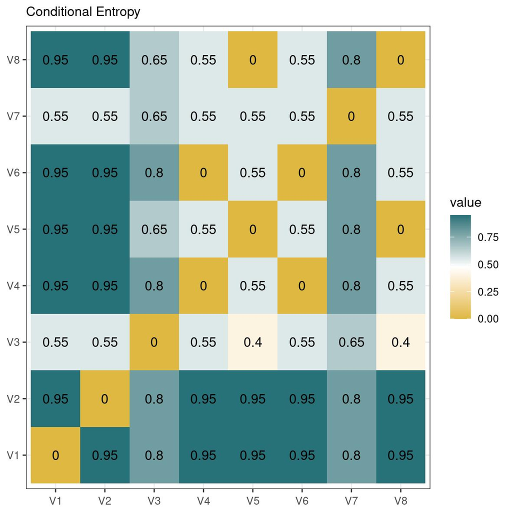

```r
c <- conditional.entropy(x = x, y = y)
kable(c)
```

| x |
| --- |
| 0.7219281 |

# joint.entropy

Joint entropy is a measure of the uncertainty associated with a set of variables.

$H(X, Y) = - \sum\sum p(x, y)log[p(x,y)]$

### Usage

joint.entropy(x, y = NULL, file = “None”)

### Arguments

- x: a vector, matrix, or data.frame.
- y: a vector. y must be NULL if x is a matrix or a data.frame.
- file: In case of x been a data.frame or matrix, represent the name of output file for saving joint entropy plot.

### Value

In case of x been a data.frame or matrix, joint entropy of all variables/columns in x. Otherwise, joint entropy of x and y.

### Examples

```r
df <- data.frame("V1" = sample.int(2,5,replace=TRUE), "V2" =sample.int(2,5,replace=TRUE) , "V3" = sample.int(2,5,replace=TRUE), "V4" = sample.int(2,5,replace=TRUE),  "V5" = sample.int(2,5,replace=TRUE), "V6" = sample.int(2,5,replace=TRUE), "V7" = sample.int(2,5,replace=TRUE), "V8" = sample.int(2,5,replace=TRUE))
x <- sample.int(2, 5,replace=TRUE)
y <- sample.int(2, 5,replace=TRUE)
```

```r
j <- joint.entropy(df, file ="jointEntropy")
kable(j)
```

|  | V1 | V2 | V3 | V4 | V5 | V6 | V7 | V8 |
| --- | --- | --- | --- | --- | --- | --- | --- | --- |
| V1 | 0.7219281 | 0.7219281 | 1.3709506 | 1.3709506 | 1.3709506 | 1.5219281 | 0.7219281 | 1.3709506 |
| V2 | 0.7219281 | 0.0000000 | 0.9709506 | 0.7219281 | 0.7219281 | 0.9709506 | 0.7219281 | 0.7219281 |
| V3 | 1.3709506 | 0.9709506 | 0.9709506 | 1.5219281 | 1.3709506 | 1.5219281 | 1.3709506 | 1.5219281 |
| V4 | 1.3709506 | 0.7219281 | 1.5219281 | 0.7219281 | 1.3709506 | 1.3709506 | 1.3709506 | 1.3709506 |
| V5 | 1.3709506 | 0.7219281 | 1.3709506 | 1.3709506 | 0.7219281 | 1.5219281 | 1.3709506 | 1.3709506 |
| V6 | 1.5219281 | 0.9709506 | 1.5219281 | 1.3709506 | 1.5219281 | 0.9709506 | 1.5219281 | 1.3709506 |
| V7 | 0.7219281 | 0.7219281 | 1.3709506 | 1.3709506 | 1.3709506 | 1.5219281 | 0.7219281 | 1.3709506 |
| V8 | 1.3709506 | 0.7219281 | 1.5219281 | 1.3709506 | 1.3709506 | 1.3709506 | 1.3709506 | 0.7219281 |

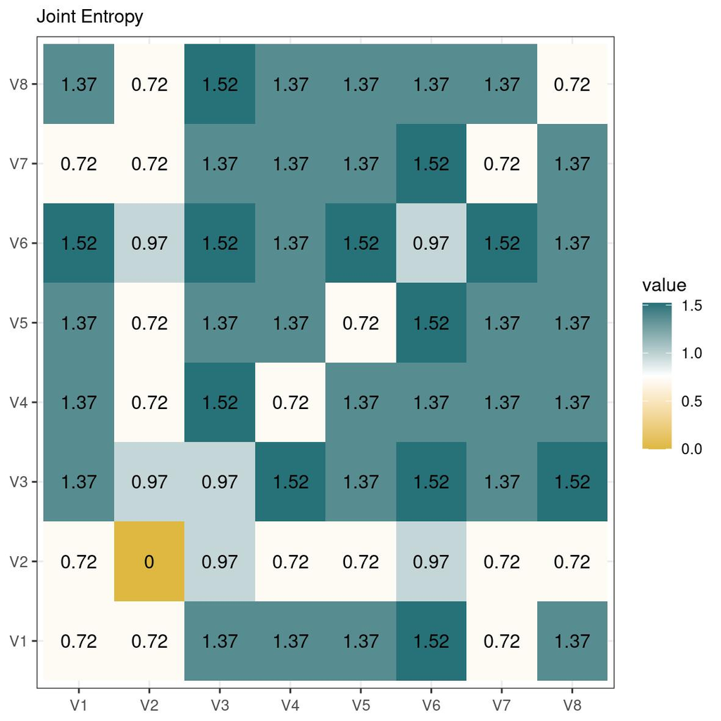

```r
j <- joint.entropy(x = x, y = y)
kable(j)
```

| x |
| --- |
| 1.370951 |

# mutual.information

Mutual information (MI) of two random variables is a measure of the mutual dependence between the two variables. More specifically, it quantifies the “amount of information” (in units such as shannons (bits), nats or hartleys) obtained about one random variable by observing the other random variable.

$I(X, Y) = \sum\sum p(x, y)log[\frac{p(x,y)}{p(x)p(y)}]$

$I(X, Y) = H(X) - H(X|Y) = H(Y) - H(Y|X) = H(X) + H(Y) - H(X, Y) = H(X, Y) - H(X|Y) - H(Y|X)$

### Usage

mutual.information(x, y = NULL, file = “None”)

### Arguments

- x: a vector, matrix, or data.frame.
- y: a vector. y must be NULL if x is a matrix or a data.frame.
- file: In case of x been a data.frame or matrix, represent the name of output file for saving mutual information plot.

### Value

In case of x been a data.frame or matrix, mutual information of all variables/columns in x. Otherwise, mutual information of x and y.

### Examples

```r
df <- data.frame("V1" = sample.int(2,5,replace=TRUE), "V2" =sample.int(2,5,replace=TRUE) , "V3" = sample.int(2,5,replace=TRUE), "V4" = sample.int(2,5,replace=TRUE),  "V5" = sample.int(2,5,replace=TRUE), "V6" = sample.int(2,5,replace=TRUE), "V7" = sample.int(2,5,replace=TRUE), "V8" = sample.int(2,5,replace=TRUE))
x <- sample.int(2, 5,replace=TRUE)
y <- sample.int(2, 5,replace=TRUE)
```

```r
m <- mutual.information(df, file ="mutualInformation")
kable(m)
```

|  | V1 | V2 | V3 | V4 | V5 | V6 | V7 | V8 |
| --- | --- | --- | --- | --- | --- | --- | --- | --- |
| V1 | 0.9709506 | 0.1709506 | 0.0199731 | 0.4199731 | 0.0199731 | 0.4199731 | 0.9709506 | 0.1709506 |
| V2 | 0.1709506 | 0.7219281 | 0.1709506 | 0.3219281 | 0.1709506 | 0.1709506 | 0.1709506 | 0.0729056 |
| V3 | 0.0199731 | 0.1709506 | 0.9709506 | 0.0199731 | 0.0199731 | 0.0199731 | 0.0199731 | 0.3219281 |
| V4 | 0.4199731 | 0.3219281 | 0.0199731 | 0.9709506 | 0.4199731 | 0.0199731 | 0.4199731 | 0.3219281 |
| V5 | 0.0199731 | 0.1709506 | 0.0199731 | 0.4199731 | 0.9709506 | 0.0199731 | 0.0199731 | 0.1709506 |
| V6 | 0.4199731 | 0.1709506 | 0.0199731 | 0.0199731 | 0.0199731 | 0.9709506 | 0.4199731 | 0.3219281 |
| V7 | 0.9709506 | 0.1709506 | 0.0199731 | 0.4199731 | 0.0199731 | 0.4199731 | 0.9709506 | 0.1709506 |
| V8 | 0.1709506 | 0.0729056 | 0.3219281 | 0.3219281 | 0.1709506 | 0.3219281 | 0.1709506 | 0.7219281 |

[figure not shown]

```r
m <- mutual.information(x = x, y = y)
kable(m)
```

| x |
| --- |
| 0.9709506 |

# correlation

Correlation is a statistic that measures the degree to which two variables move in relation to each other.

Pearson correlation, $r_{pearson}$ It is the ratio between the covariance of two variables and the product of their standard deviations;

$r_{pearson} = \frac{Cov(x,y)}{\sigma(x)\sigma(y)}$

Spearman correlation, $r_{spearman}$, is a nonparametric measure of rank correlation (statistical dependence between the rankings of two variables)

$r_{spearman} = 1 - \frac{6\sum d_i^2}{n(n^2-1)}$

### Usage

correlation(x, y = NULL, method = “Pearson”, file = “None”)

### Arguments

- x a numeric vector, matrix, or data.frame.
- y a numeric vector. y must be NULL if x is a matrix or a data.frame.
- method Pearson or Spearman method for calculate correlation. Default Pearson.
- file In case of x been a data.frame or matrix, represent the name of output file for saving mutual information plot.

### Value

In case of x been a data.frame or matrix, correlation of all variables/columns in x. Otherwise, correlation of x and y.

### Examples

```r
df <- data.frame("V1" = sample.int(3000,100,replace=FALSE), "V2" =sample.int(3000,100,replace=FALSE) , "V3" = sample.int(3000,100,replace=FALSE), "V4" = sample.int(3000,100,replace=FALSE),  "V5" = sample.int(3000,100,replace=FALSE), "V6" = sample.int(3000,100,replace=FALSE), "V7" = sample.int(3000,100,replace=FALSE), "V8" = sample.int(3000,100,replace=FALSE))
x <- c(35,23,47, 17, 10, 43, 9, 6, 28)
y <- c(30, 33, 45, 23, 8, 49, 12, 4, 31)
```

```r
correlation(x = x, y = y, method = "Pearson")
```

```
## [1] 0.9498663
```

```r
correlation(x = x, y = y, method = "Spearman")
```

```
## [1] 0.9
```

```r
correlation(x = df, method = "Pearson")
```

```
##            V2          V3          V4           V5          V6           V7
## V1 0.04276699 -0.11411832  0.09917956  0.162853000 -0.02450465 -0.084704085
## V2         NA  0.01144874 -0.05428552  0.034174211 -0.06971984  0.177765339
## V3         NA          NA -0.02111204  0.019576681  0.05766797 -0.046114227
## V4         NA          NA          NA -0.008569957  0.01887748 -0.005589433
## V5         NA          NA          NA           NA  0.05599847 -0.197018309
## V6         NA          NA          NA           NA          NA  0.094347581
## V7         NA          NA          NA           NA          NA           NA
##              V8
## V1 -0.009388131
## V2 -0.206080299
## V3 -0.029112421
## V4  0.076395492
## V5  0.043606958
## V6 -0.075333330
## V7 -0.067220256
```

```r
correlation(x = df, method = "Spearman")
```

```
##            V2           V3          V4          V5          V6          V7
## V1 0.04534053 -0.106054605  0.09022502 0.167572757 -0.03947195 -0.12976898
## V2         NA  0.006936694 -0.05768977 0.016825683 -0.06241824  0.18598260
## V3         NA           NA -0.01563756 0.003888389  0.03939994 -0.03390339
## V4         NA           NA          NA 0.001764176  0.00219622 -0.01058506
## V5         NA           NA          NA          NA  0.05982598 -0.20796880
## V6         NA           NA          NA          NA          NA  0.09196520
## V7         NA           NA          NA          NA          NA          NA
##             V8
## V1 -0.01582958
## V2 -0.21429343
## V3 -0.03145515
## V4  0.07938794
## V5  0.02484248
## V6 -0.07797180
## V7 -0.04948095
```

```r
correlation(x = df, method = "Pearson", file = "pearsonCor")
```

```
##            V2          V3          V4           V5          V6           V7
## V1 0.04276699 -0.11411832  0.09917956  0.162853000 -0.02450465 -0.084704085
## V2         NA  0.01144874 -0.05428552  0.034174211 -0.06971984  0.177765339
## V3         NA          NA -0.02111204  0.019576681  0.05766797 -0.046114227
## V4         NA          NA          NA -0.008569957  0.01887748 -0.005589433
## V5         NA          NA          NA           NA  0.05599847 -0.197018309
## V6         NA          NA          NA           NA          NA  0.094347581
## V7         NA          NA          NA           NA          NA           NA
##              V8
## V1 -0.009388131
## V2 -0.206080299
## V3 -0.029112421
## V4  0.076395492
## V5  0.043606958
## V6 -0.075333330
## V7 -0.067220256
```

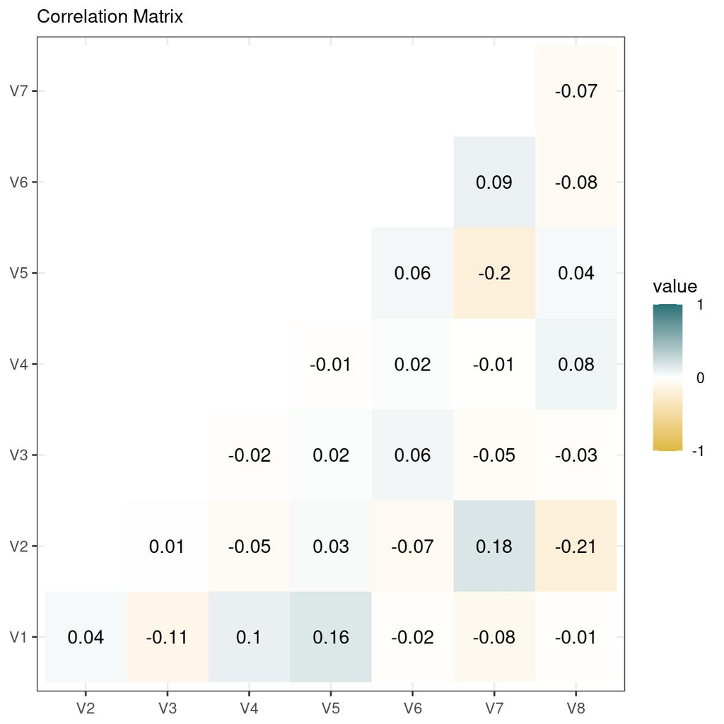

```r
correlation(x = df, method = "Spearman", file = "spearmanCor")
```

```
##            V2           V3          V4          V5          V6          V7
## V1 0.04534053 -0.106054605  0.09022502 0.167572757 -0.03947195 -0.12976898
## V2         NA  0.006936694 -0.05768977 0.016825683 -0.06241824  0.18598260
## V3         NA           NA -0.01563756 0.003888389  0.03939994 -0.03390339
## V4         NA           NA          NA 0.001764176  0.00219622 -0.01058506
## V5         NA           NA          NA          NA  0.05982598 -0.20796880
## V6         NA           NA          NA          NA          NA  0.09196520
## V7         NA           NA          NA          NA          NA          NA
##             V8
## V1 -0.01582958
## V2 -0.21429343
## V3 -0.03145515
## V4  0.07938794
## V5  0.02484248
## V6 -0.07797180
## V7 -0.04948095
```

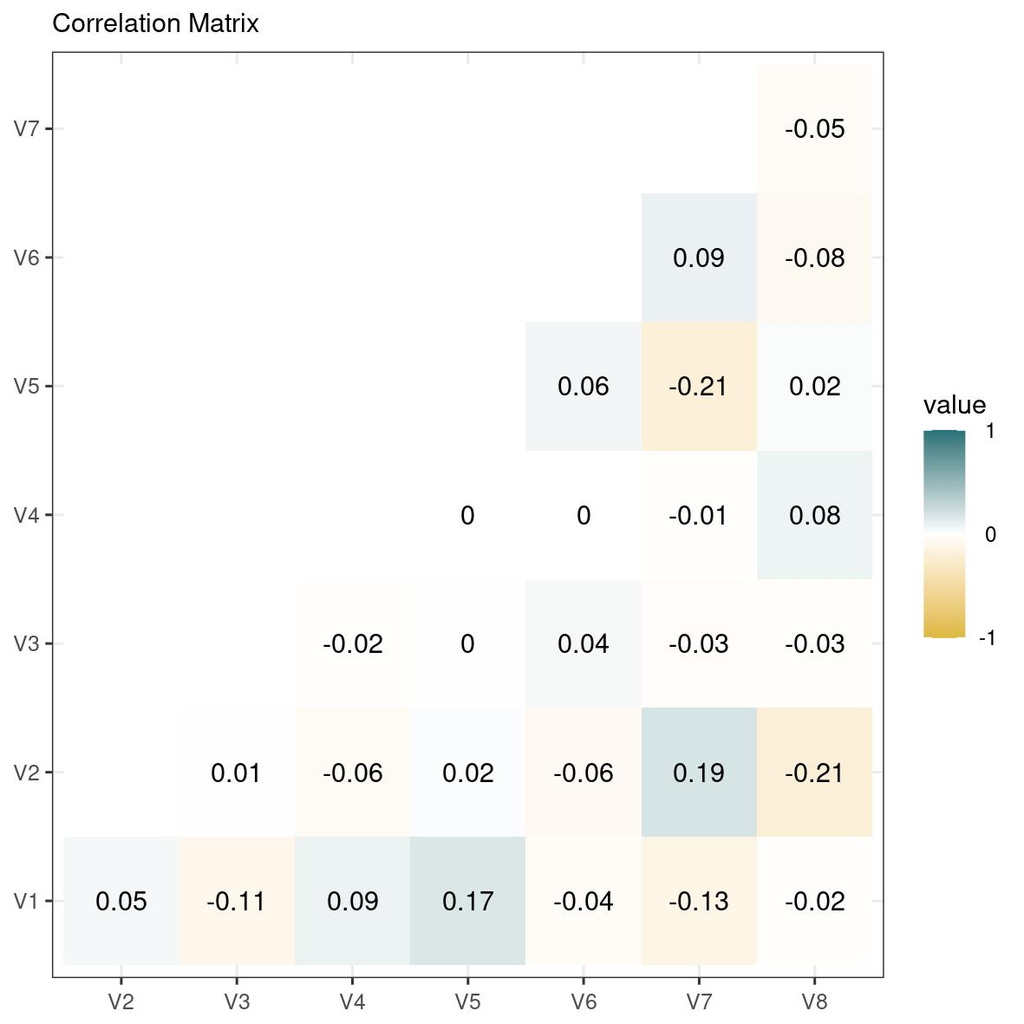

# roc_curve

The Receiver Operator Characteristic (ROC) curve is an evaluation metric for binary classification problems (can also be applied to a variable). It is a probability curve that plots the TPR against FPR.

The higher the AUC, the better the performance of the variable.

### Usage

roc.curve(x, y, file = “None”, AUC = FALSE)

### Arguments

- x: a numerical vector
- y: represent logical class TRUE/FALSE.
- file: name of output file for saving roc curve plot.
- AUC: return auc value AUC = TRUE

#### Value

dataframe wih TPR and FPR or AUC value

#### Examples

```r
random.x <- sample.int(3000,1000,replace=FALSE)
class <- c(rep(TRUE, 500), rep(FALSE, 500))
pos <- sample.int(1000, 1000)
random.y <- class[order(pos)]
perfect.x <- 1:3000
perfect.y <- c(rep(TRUE, 1500), rep(FALSE, 1500))

worst.x <- 1:3000
worst.y <- c(rep(FALSE, 1500), rep(TRUE, 1500))
```

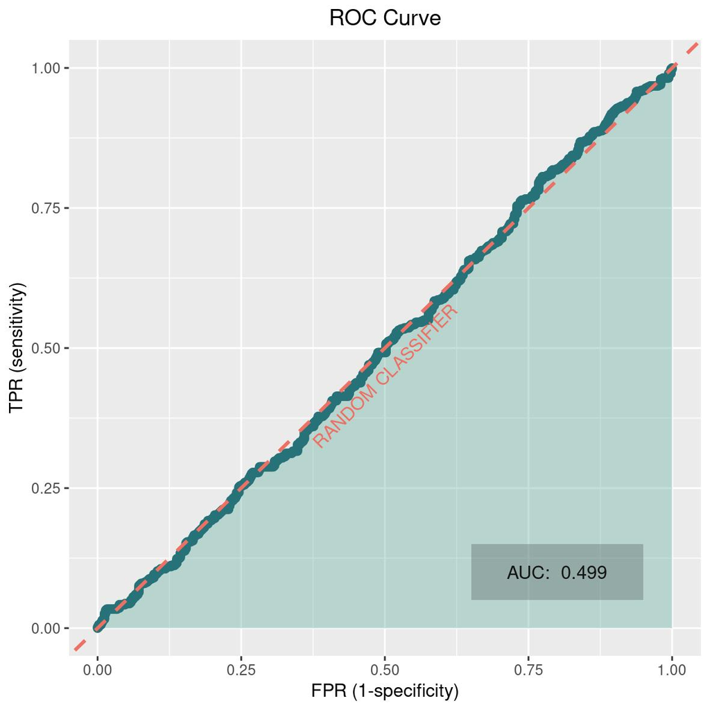

```r
randomRocCurve <- roc.curve(random.x, random.y, file= "randomRocCurve")
```

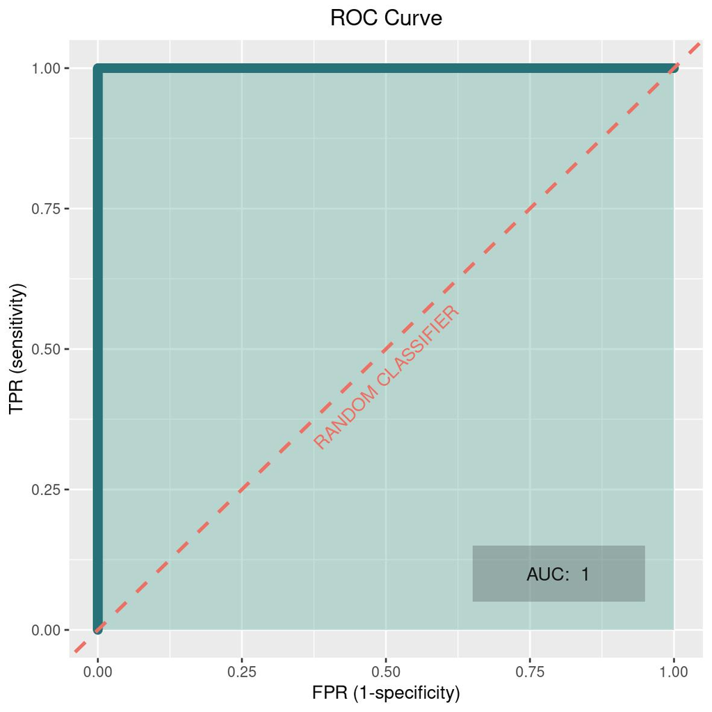

```r
perfectRocCurve <- roc.curve(perfect.x, perfect.y, file= "perfectRocCurve")
```

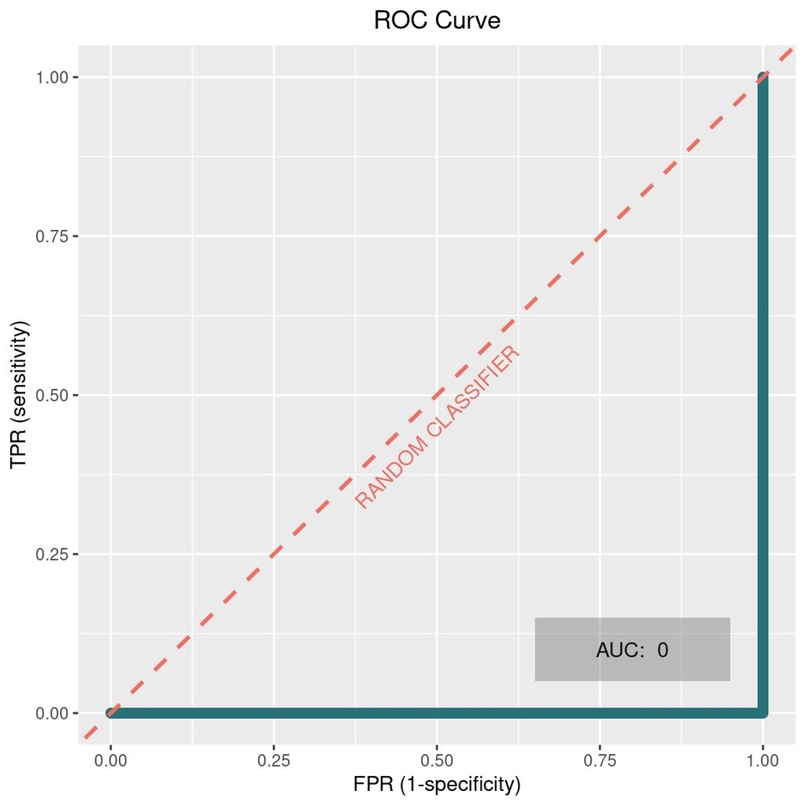

```r
worstRocCurve <- roc.curve(worst.x, worst.y, file= "worstRocCurve")
```

# filter

Given a dataframe, a metric, an upper limit and a lower limit return a filtered dataframe with the specified metric that satisfies the upper and lower bounds. For AUC metric it is required to specified class name.

#### Usage

filter( df, class, by = “AUC”, uplimit = .Machine$integer.max, lowlimit = -.Machine$integer.max ) ### Arguments

### Value

Filtered data.frame

### Examples

```r
class <- c(rep(TRUE, 5), rep(FALSE, 5))
pos <- sample.int(10, 10)
random.y <- class[order(pos)]
df.numeric <- data.frame("V1" = sample.int(3,10,replace=TRUE), "V2" = sample.int(3,10,replace=TRUE), "V3" = sample.int(3,10,replace=TRUE), "Class" =  random.y)
df.cat <- data.frame("V1" = as.factor(sample.int(3,10,replace=TRUE)), "V2" =  as.factor(sample.int(3,10,replace=TRUE)),  "V4" =  as.factor(sample.int(3,10,replace=TRUE)), "Class" =  random.y)
```

```r
filter(df.numeric, class = "Class", by = "AUC", uplimit = 1, lowlimit = 0.5)
```

```
##   V1   V2   V3
## 0.68 0.40 0.48
```

```
##    V1 Class
## 1   2  TRUE
## 2   3  TRUE
## 3   1  TRUE
## 4   2 FALSE
## 5   3 FALSE
## 6   3 FALSE
## 7   2  TRUE
## 8   1  TRUE
## 9   1 FALSE
## 10  1 FALSE
```

```r
filter(df.numeric, class = "Class", by = "Variance", uplimit = 100, lowlimit = 0)
```

```
##    V1 V2 V3 Class
## 1   2  1  3  TRUE
## 2   3  2  3  TRUE
## 3   1  3  3  TRUE
## 4   2  1  3 FALSE
## 5   3  3  1 FALSE
## 6   3  3  2 FALSE
## 7   2  3  1  TRUE
## 8   1  3  2  TRUE
## 9   1  2  1 FALSE
## 10  1  1  3 FALSE
```

```r
filter(df.cat, class = "Class", by = "Entropy", uplimit = 2, lowlimit = 0)
```

```
##    V1 V2 V4 Class
## 1   2  3  1  TRUE
## 2   1  1  3  TRUE
## 3   2  2  2  TRUE
## 4   3  3  2 FALSE
## 5   2  3  3 FALSE
## 6   2  1  1 FALSE
## 7   2  3  3  TRUE
## 8   1  2  2  TRUE
## 9   2  3  3 FALSE
## 10  3  2  3 FALSE
```

```r
filter(df.cat, class = "Class", by = "Entropy")
```

```
##    V1 V2 V4 Class
## 1   2  3  1  TRUE
## 2   1  1  3  TRUE
## 3   2  2  2  TRUE
## 4   3  3  2 FALSE
## 5   2  3  3 FALSE
## 6   2  1  1 FALSE
## 7   2  3  3  TRUE
## 8   1  2  2  TRUE
## 9   2  3  3 FALSE
## 10  3  2  3 FALSE
```

# visualize.infotheo.matrix

Heatmap plot of theory information metrics

### Usage

visualize.infotheo.matrix( df, type, file = “None”, colors = c(“#DEB841”, “white”, “#267278”) )

### Arguments

df: Conditional Entropy, Joint Entropy or Mutual Information data.frame or matrix.

type: Type of theory information metric. Character

file: In case you want to save the plot, file represents output file name.

colors: Three colors for the gradient. Default c(“#DEB841”, “white”, “#267278”).

### Value

Heatmap of given dataframe

### Example

```r
df <- data.frame("V1" = sample.int(2,5,replace=TRUE), "V2" =sample.int(2,5,replace=TRUE) , "V3" = sample.int(2,5,replace=TRUE), "V4" = sample.int(2,5,replace=TRUE),  "V5" = sample.int(2,5,replace=TRUE), "V6" = sample.int(2,5,replace=TRUE), "V7" = sample.int(2,5,replace=TRUE), "V8" = sample.int(2,5,replace=TRUE))
ce <- conditional.entropy(df)
je <- joint.entropy(df)
mi <- mutual.information(df)
```

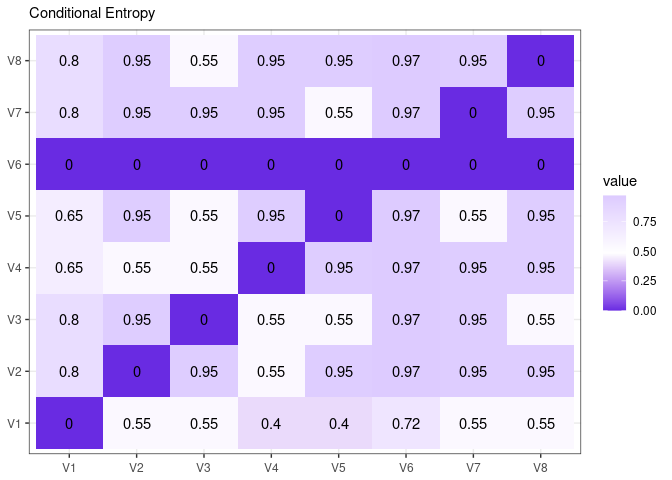

```r
p <- visualize.infotheo.matrix(ce, type = "Conditional Entropy", colors = c("#692be2", "White", "#ddcbff"))
print(p)
```

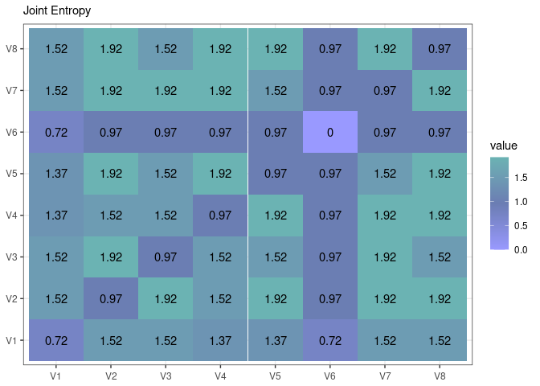

```r
p <- visualize.infotheo.matrix(je, type = "Joint Entropy", colors = c("#9999ff", "#6b7db3", "#6bb3b3"))
print(p)
```

[figure not shown]

```r
p <- visualize.infotheo.matrix(je, type = "Mutual Information", colors = c("#ffd699", "White", "#b3966b"))
print(p)
```